# Untitled

B12207073

2026-10-25

```r
pkgs <- c("tidyverse", "haven", "janitor", "stringr", "scales", "knitr")
to_install <- setdiff(pkgs, rownames(installed.packages()))
if (length(to_install) > 0) install.packages(to_install)
invisible(lapply(pkgs, library, character.only = TRUE))
dir.create("outputs", showWarnings = FALSE)

# 讀取資料集
demo <- read_xpt("DEMO_L.XPT") %>% clean_names()
bmx  <- read_xpt("BMX_L.XPT")  %>% clean_names()
bpx  <- read_xpt("BPXO_L.XPT") %>% clean_names()

# 確認受試者 ID (seqn) 無重複
stopifnot(!anyDuplicated(demo$seqn))
stopifnot(!anyDuplicated(bmx$seqn))
stopifnot(!anyDuplicated(bpx$seqn))

# 篩選 >= 20 歲之成年人並將性別轉為 Factor
demo_adult <- demo %>%
  transmute(
    seqn,
    age = ridageyr,
    sex = factor(riagendr, levels = c(1, 2), labels = c("Male", "Female"))
  ) %>%
  filter(age >= 20)
```

# Data Cleaning

```r
clean_outlier_var <- function(x, lo_bound, hi_bound) {
  range_flag <- x < lo_bound | x > hi_bound
  q <- quantile(x, probs = c(0.25, 0.75), na.rm = TRUE, names = FALSE)
  iqr <- q[2] - q[1]
  iqr_flag <- x < (q[1] - 1.5 * iqr) | x > (q[2] + 1.5 * iqr)

  # (3) MAD-based robust z-score rule
  med <- median(x, na.rm = TRUE)
  mad_raw <- mad(x, center = med, constant = 1, na.rm = TRUE)
  if (is.na(mad_raw) || mad_raw == 0) {
    mad_flag <- rep(FALSE, length(x))
  } else {
    robust_z <- abs(x - med) / (1.4826 * mad_raw)
    mad_flag <- robust_z > 3.5
  }

  flag <- !is.na(x) & (range_flag | iqr_flag | mad_flag)
  ifelse(flag, NA_real_, x)
}


bmi_clean_df <- bmx %>%
  transmute(
    seqn,
    bmi_raw = bmxbmi,
    bmi_clean = clean_outlier_var(bmxbmi, lo_bound = 10, hi_bound = 80),
    bmi_flag = !is.na(bmi_raw) & is.na(bmi_clean)
  )

dat_bmi <- demo_adult %>%
  left_join(bmi_clean_df, by = "seqn")
```

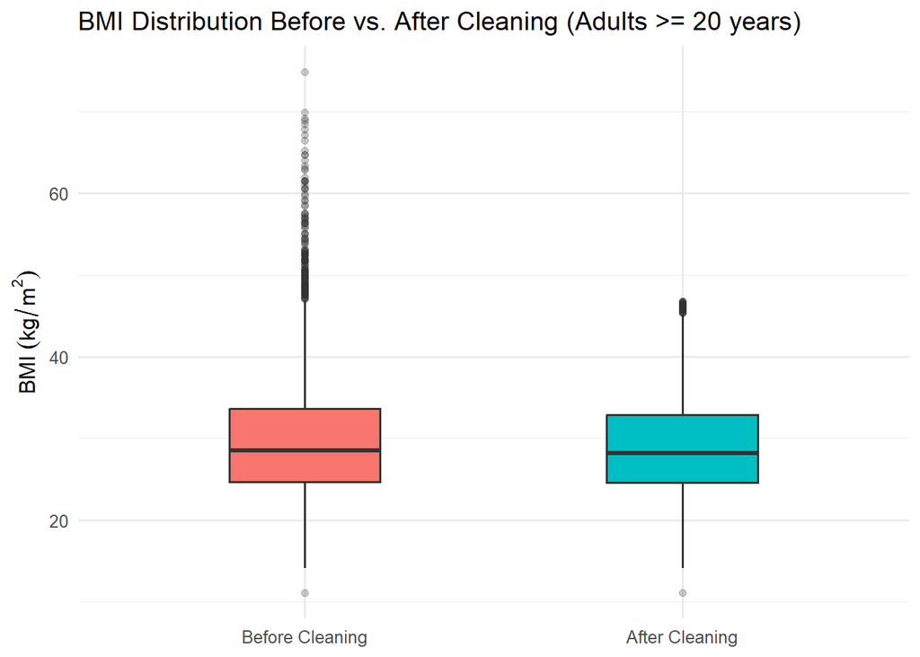

```r
dat_bmi_long <- dat_bmi %>%
  select(seqn, `Before Cleaning` = bmi_raw, `After Cleaning` = bmi_clean) %>%
  pivot_longer(cols = -seqn, names_to = "stage", values_to = "bmi") %>%
  mutate(stage = factor(stage, levels = c("Before Cleaning", "After Cleaning")))

p_bmi_compare <- ggplot(dat_bmi_long, aes(x = stage, y = bmi, fill = stage)) +
  geom_boxplot(width = 0.4, outlier.alpha = 0.25, na.rm = TRUE) +
  labs(
    title = "BMI Distribution Before vs. After Cleaning (Adults >= 20 years)",
    x = NULL, y = expression(BMI~(kg/m^2))
  ) +
  theme_minimal(base_size = 12) +
  theme(legend.position = "none")

print(p_bmi_compare)
```

```r
sbp_cols <- names(bpx)[str_detect(names(bpx), "^bpxo?sy[1-3]$")]
dbp_cols <- names(bpx)[str_detect(names(bpx), "^bpxo?di[1-3]$")]

# 建立 bpx_clean：對每個 SBP 與 DBP 欄位進行清理
bpx_clean <- bpx %>%
  mutate(
    # 保留原始平均 SBP
    sbp_mean_raw = rowMeans(across(all_of(sbp_cols)), na.rm = TRUE),
    dbp_mean_raw = rowMeans(across(all_of(dbp_cols)), na.rm = TRUE),
    across(all_of(sbp_cols), ~ clean_outlier_var(.x, 70, 260), .names = "{.col}_clean"),
    across(all_of(dbp_cols), ~ clean_outlier_var(.x, 40, 150), .names = "{.col}_clean")
  ) %>%
  mutate(
    sbp_mean_raw = ifelse(is.nan(sbp_mean_raw), NA_real_, sbp_mean_raw),
    dbp_mean_raw = ifelse(is.nan(dbp_mean_raw), NA_real_, dbp_mean_raw),
    # 計算清理後的個人平均 SBP 與 DBP
    sbp_mean_clean = rowMeans(across(all_of(paste0(sbp_cols, "_clean"))), na.rm = TRUE),
    dbp_mean_clean = rowMeans(across(all_of(paste0(dbp_cols, "_clean"))), na.rm = TRUE),
    sbp_mean_clean = ifelse(is.nan(sbp_mean_clean), NA_real_, sbp_mean_clean),
    dbp_mean_clean = ifelse(is.nan(dbp_mean_clean), NA_real_, dbp_mean_clean)
  )

# 建立最終成年人分析資料集
dat_week5 <- dat_bmi %>%
  left_join(
    bpx_clean %>% select(seqn, sbp_mean_raw, sbp_mean_clean, dbp_mean_raw, dbp_mean_clean),
    by = "seqn"
  )
```

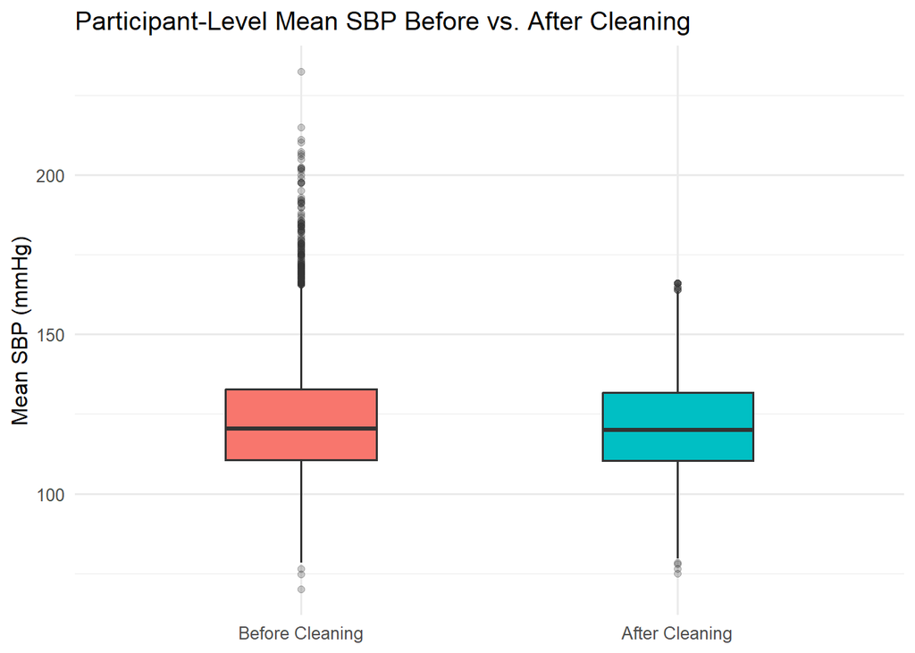

```r
dat_sbp_long <- dat_week5 %>%
  select(seqn, `Before Cleaning` = sbp_mean_raw, `After Cleaning` = sbp_mean_clean) %>%
  pivot_longer(cols = -seqn, names_to = "stage", values_to = "sbp") %>%
  mutate(stage = factor(stage, levels = c("Before Cleaning", "After Cleaning")))

p_sbp_compare <- ggplot(dat_sbp_long, aes(x = stage, y = sbp, fill = stage)) +
  geom_boxplot(width = 0.4, outlier.alpha = 0.25, na.rm = TRUE) +
  labs(
    title = "Participant-Level Mean SBP Before vs. After Cleaning",
    x = NULL, y = "Mean SBP (mmHg)"
  ) +
  theme_minimal(base_size = 12) +
  theme(legend.position = "none")

print(p_sbp_compare)
```

```r
miss_summary <- bind_rows(
  tibble(variable = "BMI", stage = "Before", n_miss = sum(is.na(dat_week5$bmi_raw)), n_tot = nrow(dat_week5)),
  tibble(variable = "BMI", stage = "After",  n_miss = sum(is.na(dat_week5$bmi_clean)), n_tot = nrow(dat_week5)),
  tibble(variable = "Mean SBP", stage = "Before", n_miss = sum(is.na(dat_week5$sbp_mean_raw)), n_tot = nrow(dat_week5)),
  tibble(variable = "Mean SBP", stage = "After",  n_miss = sum(is.na(dat_week5$sbp_mean_clean)), n_tot = nrow(dat_week5))
) %>%
  mutate(
    p_miss = n_miss / n_tot,
    stage = factor(stage, levels = c("Before", "After"))
  )

kable(miss_summary, digits = 3, caption = "Missingness Before and After Cleaning for BMI and Mean SBP")
```

Missingness Before and After Cleaning for BMI and Mean SBP

| variable | stage | n_miss | n_tot | p_miss |
| --- | --- | --- | --- | --- |
| BMI | Before | 1839 | 7809 | 0.235 |
| BMI | After | 2016 | 7809 | 0.258 |
| Mean SBP | Before | 1946 | 7809 | 0.249 |
| Mean SBP | After | 2055 | 7809 | 0.263 |

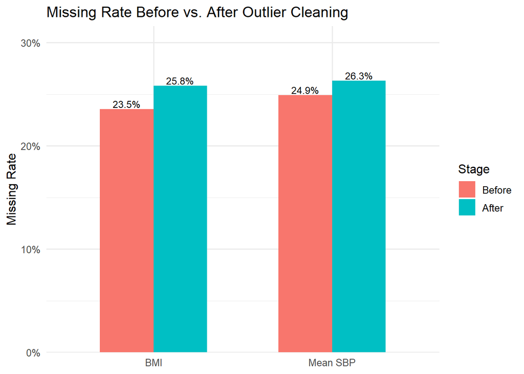

```r
p_miss <- ggplot(miss_summary, aes(x = variable, y = p_miss, fill = stage)) +
  geom_col(width = 0.6, position = "dodge") +
  geom_text(
    aes(label = paste0(percent(p_miss, accuracy = 0.1))),
    position = position_dodge(width = 0.6), vjust = -0.2, size = 3.3
  ) +
  scale_y_continuous(labels = percent, expand = expansion(mult = c(0, 0.2))) +
  labs(title = "Missing Rate Before vs. After Outlier Cleaning", x = NULL, y = "Missing Rate", fill = "Stage") +
  theme_minimal(base_size = 12)

print(p_miss)
```

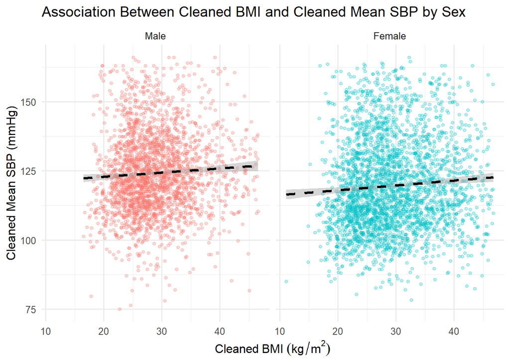

```r
p_scatter <- dat_week5 %>%
  drop_na(bmi_clean, sbp_mean_clean, sex) %>%
  ggplot(aes(x = bmi_clean, y = sbp_mean_clean, color = sex)) +
  geom_point(alpha = 0.25, size = 1.2) +
  geom_smooth(method = "lm", se = TRUE, color = "black", linetype = "dashed") +
  facet_wrap(~ sex) +
  labs(
    title = "Association Between Cleaned BMI and Cleaned Mean SBP by Sex",
    x = expression(Cleaned~BMI~(kg/m^2)),
    y = "Cleaned Mean SBP (mmHg)"
  ) +
  theme_minimal(base_size = 12) +
  theme(legend.position = "none")

print(p_scatter)
```

# Week 6: Repeated-Measure

```r
bp_long <- bpx %>%
  semi_join(demo_adult %>% select(seqn), by = "seqn") %>%
  select(seqn, all_of(c(sbp_cols, dbp_cols))) %>%
  pivot_longer(
    cols = -seqn,
    names_to = c("measure", "trial"),
    names_pattern = "^bpxo?(sy|di)([1-3])$",
    values_to = "value"
  ) %>%
  mutate(
    measure = recode(measure, "sy" = "SBP", "di" = "DBP"),
    trial = as.integer(trial),
    trial_f = factor(trial, levels = 1:3, labels = c("Trial 1", "Trial 2", "Trial 3"))
  )

trial_summary <- bp_long %>%
  group_by(measure, trial_f) %>%
  summarise(
    n = sum(!is.na(value)),
    mean = mean(value, na.rm = TRUE),
    median = median(value, na.rm = TRUE),
    sd = sd(value, na.rm = TRUE),
    q1 = quantile(value, 0.25, na.rm = TRUE),
    q3 = quantile(value, 0.75, na.rm = TRUE),
    .groups = "drop"
  )

kable(trial_summary, digits = 1, caption = "Raw BP Summary Across Repeated Trials (Trials 1-3)")
```

Raw BP Summary Across Repeated Trials (Trials 1-3)

| measure | trial_f | n | mean | median | sd | q1 | q3 |
| --- | --- | --- | --- | --- | --- | --- | --- |
| DBP | Trial 1 | 5863 | 75.3 | 75 | 11.4 | 68 | 82 |
| DBP | Trial 2 | 5856 | 74.6 | 74 | 11.3 | 67 | 81 |
| DBP | Trial 3 | 5843 | 74.3 | 74 | 11.2 | 67 | 81 |
| SBP | Trial 1 | 5863 | 123.1 | 121 | 18.5 | 110 | 133 |
| SBP | Trial 2 | 5856 | 122.9 | 120 | 18.5 | 110 | 133 |
| SBP | Trial 3 | 5843 | 122.7 | 120 | 18.4 | 110 | 132 |

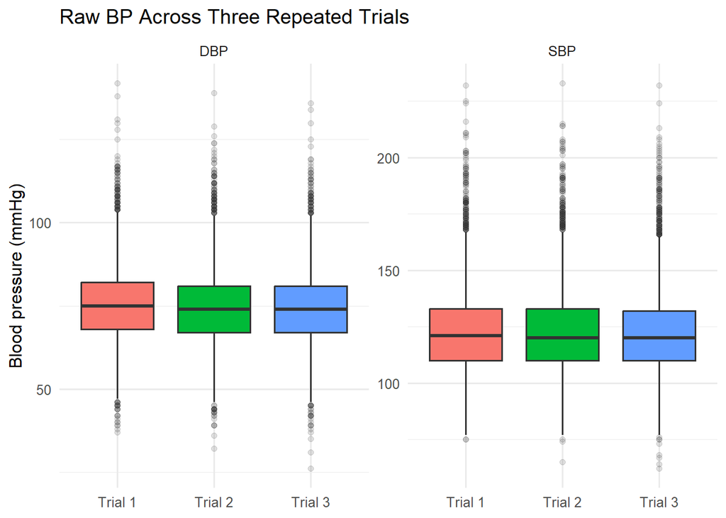

```r
p_trial <- ggplot(bp_long, aes(x = trial_f, y = value, fill = trial_f)) +
  geom_boxplot(outlier.alpha = 0.15, na.rm = TRUE) +
  facet_wrap(~ measure, scales = "free_y") +
  labs(title = "Raw BP Across Three Repeated Trials", x = NULL, y = "Blood pressure (mmHg)") +
  theme_minimal(base_size = 12) +
  theme(legend.position = "none")

print(p_trial)
```

Do the three BP trials look similar at the population level?

是，三次的舒張壓和收縮壓平均值、中位數都相近，盒鬚圖上也可以看到不受次序先後影響

```r
sbp_change <- bp_long %>%
  filter(measure == "SBP") %>%
  select(seqn, trial, value) %>%
  mutate(trial = paste0("trial", trial)) %>%
  pivot_wider(names_from = trial, values_from = value) %>%
  mutate(
    delta_31 = trial3 - trial1,
    change_direction = case_when(
      is.na(delta_31) ~ NA_character_,
      delta_31 < 0 ~ "Trial 3 lower",
      delta_31 > 0 ~ "Trial 3 higher",
      TRUE ~ "No change"
    )
  )

kable(sbp_change %>% count(change_direction), caption = "Direction of Within-Person SBP Change (Trial 3 vs. Trial 1)")
```

Direction of Within-Person SBP Change (Trial 3 vs. Trial 1)

| change_direction | n |
| --- | --- |
| No change | 409 |
| Trial 3 higher | 2647 |
| Trial 3 lower | 2787 |
| NA | 221 |

```r
sbp_change_sum <- sbp_change %>%
  summarise(
    n_complete = sum(!is.na(delta_31)),
    mean_change = mean(delta_31, na.rm = TRUE),
    median_change = median(delta_31, na.rm = TRUE),
    q1 = quantile(delta_31, 0.25, na.rm = TRUE),
    q3 = quantile(delta_31, 0.75, na.rm = TRUE)
  )
kable(sbp_change_sum, digits = 2, caption = "Summary of Within-Person SBP Change (Trial 3 - Trial 1)")
```

Summary of Within-Person SBP Change (Trial 3 - Trial 1)

| n_complete | mean_change | median_change | q1 | q3 |
| --- | --- | --- | --- | --- |
| 5843 | -0.32 | 0 | -4 | 4 |

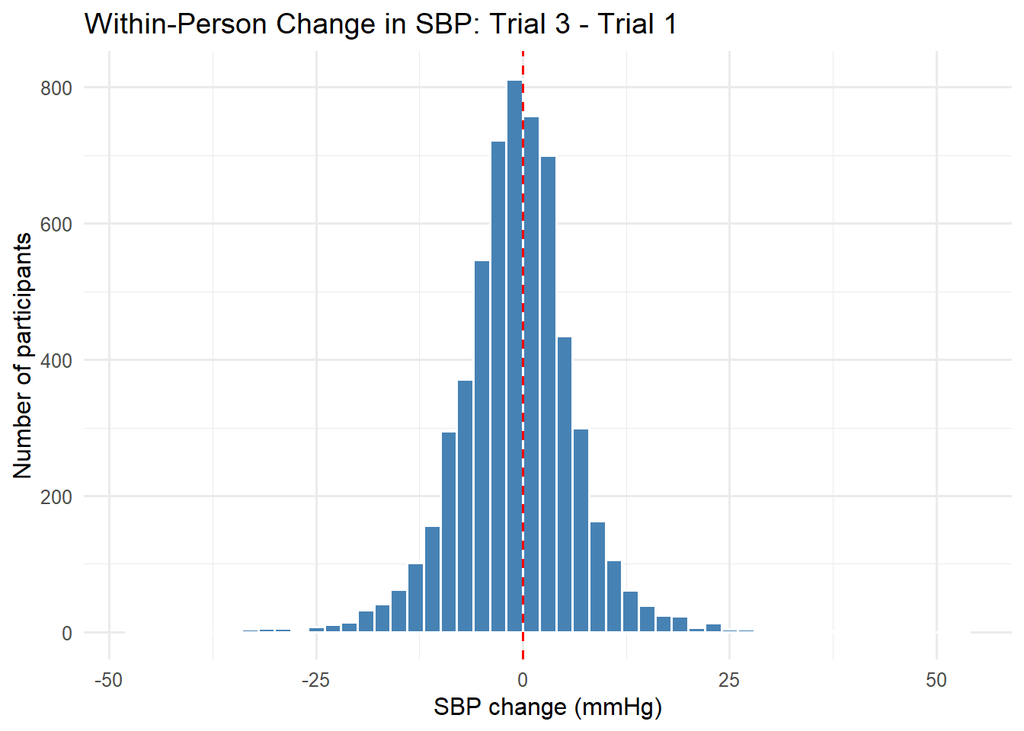

```r
# Histogram of Trial 3 - Trial 1
p_change <- sbp_change %>%
  drop_na(delta_31) %>%
  ggplot(aes(x = delta_31)) +
  geom_histogram(binwidth = 2, boundary = 0, color = "white", fill = "steelblue") +
  geom_vline(xintercept = 0, linetype = 2, color = "red") +
  labs(title = "Within-Person Change in SBP: Trial 3 - Trial 1",
       x = "SBP change (mmHg)", y = "Number of participants") +
  theme_minimal(base_size = 12)
print(p_change)
```

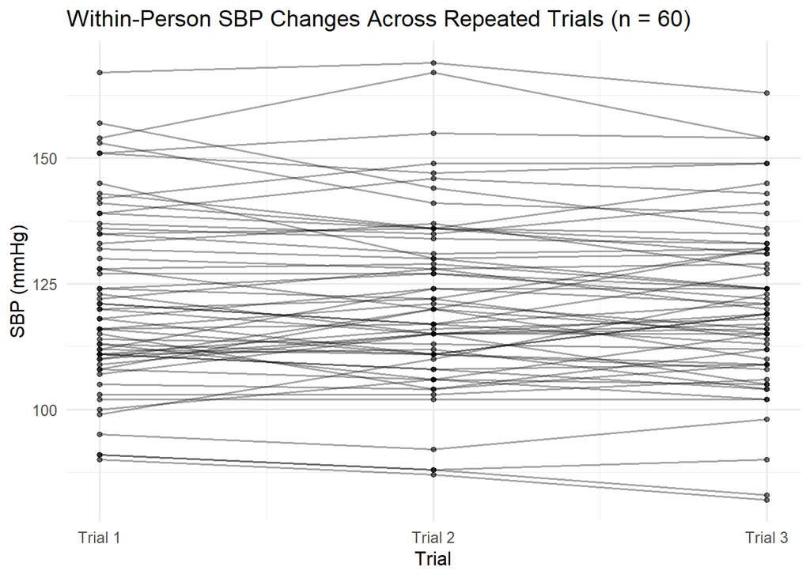

```r
# Spaghetti plot for 60 participants
complete_ids <- sbp_change %>%
  drop_na(trial1, trial2, trial3) %>%
  arrange(seqn) %>%
  slice_head(n = 60) %>%
  pull(seqn)

p_lines <- bp_long %>%
  filter(measure == "SBP", seqn %in% complete_ids) %>%
  ggplot(aes(x = trial, y = value, group = factor(seqn))) +
  geom_line(alpha = 0.35) +
  geom_point(alpha = 0.5, size = 1.2) +
  scale_x_continuous(breaks = 1:3, labels = c("Trial 1", "Trial 2", "Trial 3")) +
  labs(title = "Within-Person SBP Changes Across Repeated Trials (n = 60)",
       x = "Trial", y = "SBP (mmHg)") +
  theme_minimal(base_size = 12)
print(p_lines)
```

多數受試者在第 1 次與第 3 次測量間發生血壓改變

```r
bp_within_raw <- bp_long %>%
  group_by(seqn, measure) %>%
  summarise(
    n_readings = sum(!is.na(value)),
    mean_bp = ifelse(n_readings > 0, mean(value, na.rm = TRUE), NA_real_),
    range_bp = ifelse(n_readings >= 2, max(value, na.rm = TRUE) - min(value, na.rm = TRUE), NA_real_),
    sd_bp = ifelse(n_readings >= 2, sd(value, na.rm = TRUE), NA_real_),
    .groups = "drop"
  )

within_summary_raw <- bp_within_raw %>%
  filter(n_readings >= 2) %>%
  group_by(measure) %>%
  summarise(
    median_range = median(range_bp, na.rm = TRUE),
    p90_range = quantile(range_bp, 0.90, na.rm = TRUE),
    median_sd = median(sd_bp, na.rm = TRUE),
    .groups = "drop"
  )

kable(within_summary_raw, digits = 1, caption = "Raw Within-Person BP Variability Summary")
```

Raw Within-Person BP Variability Summary

| measure | median_range | p90_range | median_sd |
| --- | --- | --- | --- |
| DBP | 4 | 9 | 2.0 |
| SBP | 6 | 14 | 3.2 |

SBP 的個人內標準差中位數為 $3.2\text{ mmHg}$，而 DBP 為 $2.0\text{ mmHg}$。收縮壓變異大，可能有其他因素影響

# Part B: Homework

```r
sbp_clean_cols <- paste0(sbp_cols, "_clean")
dbp_clean_cols <- paste0(dbp_cols, "_clean")

bp_clean_long <- bpx_clean %>%
  semi_join(demo_adult %>% select(seqn), by = "seqn") %>%
  select(seqn, all_of(c(sbp_clean_cols, dbp_clean_cols))) %>%
  pivot_longer(
    cols = -seqn,
    names_to = c("measure", "trial"),
    names_pattern = "^bpxo?(sy|di)([1-3])_clean$",
    values_to = "value"
  ) %>%
  mutate(
    measure = recode(measure, "sy" = "SBP", "di" = "DBP"),
    trial = as.integer(trial)
  )

# 彙整每位受試者的 Trial 1、平均值、中位數與個人內變異指標
bp_person_summary <- bp_clean_long %>%
  group_by(seqn, measure) %>%
  summarise(
    n_readings = sum(!is.na(value)),
    trial1 = value[trial == 1],
    mean_bp = ifelse(n_readings > 0, mean(value, na.rm = TRUE), NA_real_),
    median_bp = ifelse(n_readings > 0, median(value, na.rm = TRUE), NA_real_),
    range_bp = ifelse(n_readings >= 2, max(value, na.rm = TRUE) - min(value, na.rm = TRUE), NA_real_),
    sd_bp = ifelse(n_readings >= 2, sd(value, na.rm = TRUE), NA_real_),
    .groups = "drop"
  ) %>%
  pivot_wider(
    names_from = measure,
    values_from = c(n_readings, trial1, mean_bp, median_bp, range_bp, sd_bp),
    names_glue = "{measure}_{.value}"
  )
```

```r
classify_bp <- function(sbp, dbp) {
  case_when(
    is.na(sbp) | is.na(dbp) ~ NA_character_,
    sbp >= 140 | dbp >= 90  ~ "Stage 2",
    sbp >= 130 | dbp >= 80  ~ "Stage 1",
    sbp >= 120 & dbp < 80   ~ "Elevated",
    sbp < 120  & dbp < 80   ~ "Normal"
  ) %>%
    factor(levels = c("Normal", "Elevated", "Stage 1", "Stage 2"))
}

bp_classified <- bp_person_summary %>%
  mutate(
    cat_trial1 = classify_bp(SBP_trial1, DBP_trial1),
    cat_mean   = classify_bp(SBP_mean_bp, DBP_mean_bp),
    cat_median = classify_bp(SBP_median_bp, DBP_median_bp)
  ) %>%
  drop_na(cat_trial1, cat_mean) %>%
  mutate(
    reclassified = (cat_trial1 != cat_mean)
  )
```

```r
reclass_prop <- mean(bp_classified$reclassified)
cat("Overall Reclassification Proportion (Trial 1 vs. Mean BP):", percent(reclass_prop, accuracy = 0.1), "\n")
```

```
## Overall Reclassification Proportion (Trial 1 vs. Mean BP): 16.9%
```

```r
cross_tab <- bp_classified %>%
  count(cat_trial1, cat_mean) %>%
  pivot_wider(names_from = cat_mean, values_from = n, values_fill = 0)

kable(cross_tab, caption = "Cross-Tabulation: Trial 1 BP Category (Rows) vs. Mean BP Category (Columns)")
```

Cross-Tabulation: Trial 1 BP Category (Rows) vs. Mean BP Category (Columns)

| cat_trial1 | Normal | Elevated | Stage 1 | Stage 2 |
| --- | --- | --- | --- | --- |
| Normal | 2313 | 108 | 37 | 0 |
| Elevated | 169 | 554 | 84 | 0 |
| Stage 1 | 96 | 171 | 1027 | 91 |
| Stage 2 | 2 | 5 | 197 | 823 |

16.9%受試者在改標準改採為三次平均後，分類組別改變

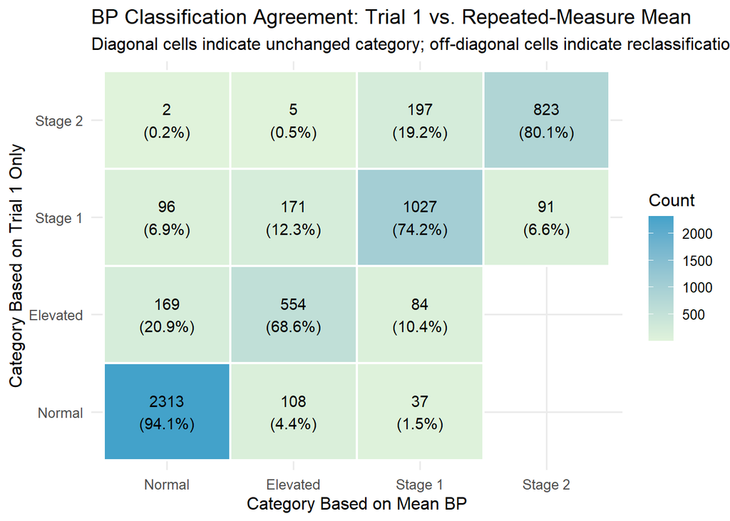

```r
heatmap_df <- bp_classified %>%
  count(cat_trial1, cat_mean) %>%
  group_by(cat_trial1) %>%
  mutate(prop_row = n / sum(n)) %>%
  ungroup()

p_heatmap <- ggplot(heatmap_df, aes(x = cat_mean, y = cat_trial1, fill = n)) +
  geom_tile(color = "white", linewidth = 0.8) +
  geom_text(aes(label = paste0(n, "\n(", percent(prop_row, accuracy = 0.1), ")")), size = 3.8) +
  scale_fill_gradient(low = "#e0f3db", high = "#43a2ca") +
  labs(
    title = "BP Classification Agreement: Trial 1 vs. Repeated-Measure Mean",
    subtitle = "Diagonal cells indicate unchanged category; off-diagonal cells indicate reclassification",
    x = "Category Based on Mean BP",
    y = "Category Based on Trial 1 Only",
    fill = "Count"
  ) +
  theme_minimal(base_size = 12)

print(p_heatmap)
```

右下角是被改成較高的組別，左上角是被改成較低的組別，在被重新分組的組別中，改低人數大於改高人數。

```r
var_reclass <- bp_classified %>%
  filter(SBP_n_readings >= 2, !is.na(SBP_sd_bp)) %>%
  mutate(
    sbp_var_group = ntile(SBP_sd_bp, 3),
    sbp_var_group = factor(
      sbp_var_group,
      levels = 1:3,
      labels = c("Low Variability (T1)", "Medium Variability (T2)", "High Variability (T3)")
    )
  ) %>%
  group_by(sbp_var_group) %>%
  summarise(
    n_participants = n(),
    median_sbp_sd = median(SBP_sd_bp, na.rm = TRUE),
    n_reclassified = sum(reclassified),
    reclass_rate = mean(reclassified),
    .groups = "drop"
  )

kable(var_reclass, digits = 3, caption = "Reclassification Rate Across Within-Person SBP Variability Groups")
```

Reclassification Rate Across Within-Person SBP Variability Groups

| sbp_var_group | n_participants | median_sbp_sd | n_reclassified | reclass_rate |
| --- | --- | --- | --- | --- |
| Low Variability (T1) | 1883 | 1.528 | 145 | 0.077 |
| Medium Variability (T2) | 1883 | 3.055 | 288 | 0.153 |
| High Variability (T3) | 1883 | 5.774 | 527 | 0.280 |

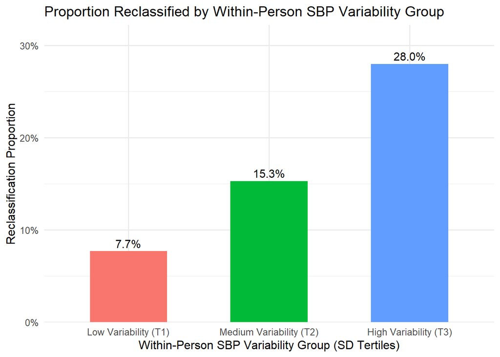

```r
p_var_reclass <- ggplot(var_reclass, aes(x = sbp_var_group, y = reclass_rate, fill = sbp_var_group)) +
  geom_col(width = 0.55) +
  geom_text(aes(label = percent(reclass_rate, accuracy = 0.1)), vjust = -0.4, size = 4) +
  scale_y_continuous(labels = percent, expand = expansion(mult = c(0, 0.15))) +
  labs(
    title = "Proportion Reclassified by Within-Person SBP Variability Group",
    x = "Within-Person SBP Variability Group (SD Tertiles)",
    y = "Reclassification Proportion"
  ) +
  theme_minimal(base_size = 12) +
  theme(legend.position = "none")

print(p_var_reclass)
```

變異數越高組別，被重新分組的比率越高

```r
comp_pairs <- tibble(
  Comparison = c("Trial 1 vs. Mean", "Trial 1 vs. Median", "Mean vs. Median"),
  Prop_Changed = c(
    mean(bp_classified$cat_trial1 != bp_classified$cat_mean, na.rm = TRUE),
    mean(bp_classified$cat_trial1 != bp_classified$cat_median, na.rm = TRUE),
    mean(bp_classified$cat_mean   != bp_classified$cat_median, na.rm = TRUE)
  )
)
kable(comp_pairs, digits = 4, caption = "Optional Challenge: Proportion of Category Changes Across Strategies")
```

Optional Challenge: Proportion of Category Changes Across Strategies

| Comparison | Prop_Changed |
| --- | --- |
| Trial 1 vs. Mean | 0.1691 |
| Trial 1 vs. Median | 0.1460 |
| Mean vs. Median | 0.0648 |

只使用第一次測量結果作為分類標準，分類被改變的機率高

結論:在群體分布上，三次重複測量的收縮壓平均值與中位數幾乎完全不變，表示分布穩定。 但在個體內變異上；多數受試者在第 1 次與第 3 次測量間發生血壓改變，個人標準差中位數為 $3.2\text{ mmHg}$。 當改以三次測量的平均值（Mean BP）取代單次測量（Trial 1）進行分級時，有 16.91% 的受試者被重新分類，其中降級人數多於升級，代表單次測量會容易高估高血壓的臨床分級，被重新分類率與個人收縮壓變異度呈現正相關。